# Project 2: Bipartite graph

Jennifer Brown

2023-12-24

For this project, when I mention “graphs”, I’m talking about the sort you’d see in a discrete math class, with vertices and edges, rather than the sort you’d see in a calculus class. We’re going to use Ti*k*z to draw the following bipartite graph:

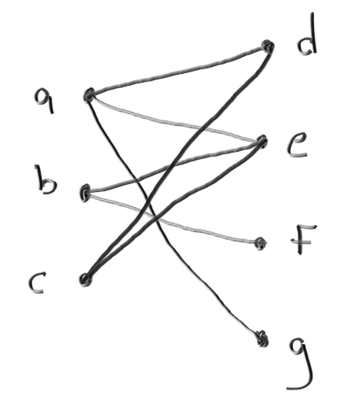

Ti*k*z has several different ways of making graphs. The one you will see in this project is the most intuitive: we will simply tell Ti*k*z where to put vertex dots and edge lines by specifying coordinates in the plane. (In a later project, we’ll see another way to draw graphs, using Ti*k*z’s graph-drawing algorithms and a different engine; it’s more powerful but less intuitive.)

## Planning with paper and pencil, and using grid lines

In this method, you need to some paper-and-pencil work up front in order to figure out where, on the plane, the vertices and edges of your graph should be located. As a rule of thumb, try to make your scale such that you’re dealing with integer values fairly near the origin, like $(4,2)$, rather than decimal values far from the origin, like $(572.0043, -82.009)$. This is just to make life easier for yourself; it’s not a hard-and-fast requirement. You can always re-scale your picture to fit it where it needs to go, and you can also fine-tune the placement of elements of your picture after you’ve got the basic picture done.

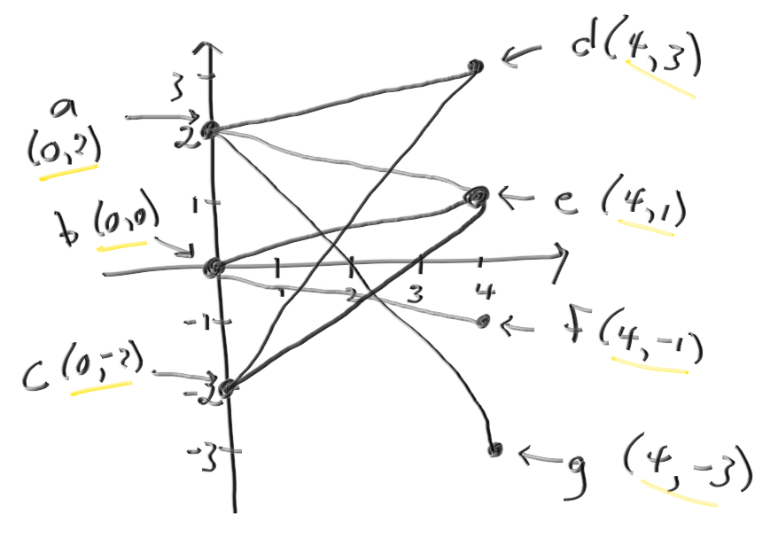

When you are making pictures by specifying coordinates for where things go, it’s helpful to have Ti*k*z draw some gridlines so that you can see if you’re placing elements as you specified in your hand-drawn picture. To do this, you use $\texttt{help lines}$ as an argument to the $\texttt{\draw}$ function, and use the $\texttt{grid}$ path operation. Ti*k*z will draw a grid (at integer values) in a rectangle whose lower left corner is the first point and whose upper right corner is the second point. I chose to have a grid containing all of the $x$- and $y$-values that I will need in my picture, plus a little wiggle room for adding labels. (I also scaled the whole thing down so that it would display correctly on the web page; note the $\texttt{[scale=0.5]}$ argument.)

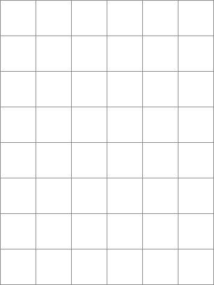

```latex
\begin{tikzpicture}[scale=0.5]
\draw [help lines] (-1,-4) grid (5,4);
\end{tikzpicture}
```

## Edges

Next, let’s add the edges. We’ve already seen how to do that in Project 1: use the $\texttt{\draw}$ command. For example, to draw the edge that goes from $(0,2)$ to $(4,3)$, we’d write $\texttt{\draw (0,2) -- (4,3);}$

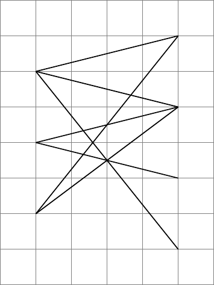

```latex
\begin{tikzpicture}[scale=0.5]

% help lines (comment out when done)
\draw [help lines] (-1,-4) grid (5,4);

% edges from vertex a
\draw (0,2) -- (4,3);
\draw (0,2) -- (4,1);
\draw (0,2) -- (4,-3);

% edges from vertex b
\draw (0,0) -- (4,1);
\draw (0,0) -- (4,-1);

% edges from vertex c
\draw (0,-2) -- (4,3);
\draw (0,-2) -- (4,1);

\end{tikzpicture}
```

Remember to comment your code! The little note $\texttt{% help lines (comment out when done)}$ reminds me that I should put a $\texttt{%}$ sign in front of the help lines command when I’m satisfied with my picture.

## The vertices: nodes in Ti*k*z

The next element we need is little dots at the vertices of our graph. The little dots will be drawn at a $\textit{node}$. (These were briefly mentioned in Project 1.) A node in Ti*k*z is a thing placed at a particular place. That’s a pretty broad description, but a node is a very flexible object: it can contain some text, an equation in math mode, a shape, or some complicated combination of these.

(A Technical Aside: we’re using a little trick here. Strictly speaking, a node in Ti*k*z is a specification of a place to put text, but you can also specify a *background* for the text. If your “background” is the shape that you actually want to position at the node, you can make the text empty so that only the background – that is, the shape – shows up. This is what we’ll do to draw the vertices.)

For our purposes, we want to put nodes at each location where a vertex should be, and put a little solid black circle at each of these nodes. The following code would place a little dot at $(0,2)$, where vertex $a$ will be:

$$\verb|\node [circle, fill, inner sep=2pt] at (0,2) {};|$$

Let’s see what the various arguments to the node mean, and how they can be modified to adjust the appearance of the vertices in the picture.

- The first two arguments to the $\verb|node|$ command, $\verb|circle|$ and $\verb|fill|$, tell Ti*k*z to make a filled-in circle.
- The default color is black.
- The next argument, $\verb|inner sep=2pt|$, tells Ti*k*z how big to make the dot. (To be precise, it tells it how much space to put between the text – which is empty – and the edge of the dot.)
- The ordered pair (this is $(0,2)$ in our example) tells Ti*k*z where to put the node.
- The empty brackets $\verb|{}|$ specifies that the spot that would ordinarily be occupied by text is to be empty (see the Technical Aside above).

For comparison, here are some dots and dot-like things that can be drawn by varying the basic dot shape above, using the two built-in shapes for nodes: $\verb|circle|$ and $\verb|rectangle|$.

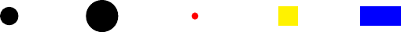

```latex
\begin{tikzpicture}

% the dot shape from above
\node [circle, fill, inner sep=2pt] at (0,0) {};

% a bigger dot
\node [circle, fill, inner sep=3.5pt] at (1,0) {};

% a smaller red dot
\node [circle, fill=red, inner sep=.75pt] at (2,0) {};

% a yellow square
\node [rectangle, fill=yellow, inner sep=3pt] at (3,0) {};

% a blue rectangle
\node [rectangle, fill=blue, inner sep=3pt] at (4,0) {\ \ \ };

\end{tikzpicture}
```

Many more variations are possible. To make dots in fancy colors, we could put $\verb|\usepackage[dvipsnames]{xcolor}|$ in the preamble to load the $\verb|dvipsnames|$ colors from the $\verb|xcolor|$ package (remembering to load it *before* we load Ti*k*z). To get additional shapes, like diamonds and stars, we can load a library called $\verb|shapes.geometric|$ using the command $\verb|\usepgflibrary{shapes.geometric}|$ (see the PGF/Ti*k*z Manual’s section on [Geometric Shapes](https://tikz.dev/library-shapes#autosec-6351)).

Once we’re satisfied with our vertex shape, we could place it at vertex $a$, like this:

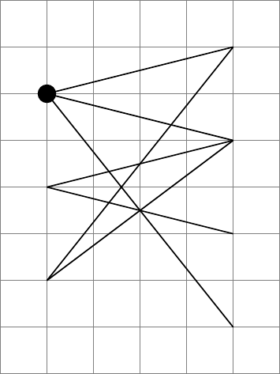

```latex
\begin{tikzpicture}[scale=0.5]

% help lines (comment out when done)
\draw [help lines] (-1,-4) grid (5,4);

% edges from vertex a
\draw (0,2) -- (4,3);
\draw (0,2) -- (4,1);
\draw (0,2) -- (4,-3);

% edges from vertex b
\draw (0,0) -- (4,1);
\draw (0,0) -- (4,-1);

% edges from vertex c
\draw (0,-2) -- (4,3);
\draw (0,-2) -- (4,1);

% dot at vertex a
\node [circle, fill, inner sep=2pt] at (0,2) {};

\end{tikzpicture}
```

Then we could repeat the command
$$\verb|\node [circle, fill, inner sep=2pt] at (0,2) {};|$$
for the six other vertices in our graph (changing $(0,2)$ to the appropriate coordinate). – But then what if, later, we decide that we wanted that little dot to be a bit bigger? or smaller? or purple? We would then need to go back and alter seven different occurrences of this command in order to make the desired changes. This is a recipe for frustration and error.

## The vertices, continued: Using styles

Enter Ti*k*z *styles*. A style is a series of arguments – in this case, to a node – that you name and declare either in the preamble, or just at the beginning of your current picture. In this project, the style for the vertices is going to be declared at the beginning of each picture – right after the beginning of the $\verb|tikzpicture|$ environment. However, if you’re going to be using a style in multiple places throughout a document, it’s best to declare it in the preamble (and to make a comment at the beginning of each picture where it’s used, saying that the style is used and what it’s called). I’m going to declare a style called $\verb|vertex|$:

$$\verb|\tikzstyle{vertex}=[circle, fill, inner sep=2pt]|$$

This command is simply taking all of the arguments we had inside the $\verb|node|$ command and packaging them inside a new argument called $\verb|vertex|$. Now we’re going to declare our $\verb|vertex|$ style at the beginning of the picture, delete the
$$\verb|\node [circle, fill, inner sep=2pt] at (0,2) {};|$$
command, and use the $\verb|vertex|$ style instead to put a vertex at each node.

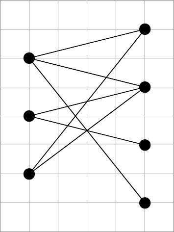

```latex
\begin{tikzpicture}[scale=0.5]

% vertex style to be used at vertex nodes
\tikzstyle{vertex}=[circle, fill, inner sep=2pt]

% help lines (comment out when done)
\draw [help lines] (-1,-4) grid (5,4);

% edges from vertex a
\draw (0,2) -- (4,3);
\draw (0,2) -- (4,1);
\draw (0,2) -- (4,-3);

% edges from vertex b
\draw (0,0) -- (4,1);
\draw (0,0) -- (4,-1);

% edges from vertex c
\draw (0,-2) -- (4,3);
\draw (0,-2) -- (4,1);

% dot at vertex a
\node [vertex] at (0,2) {};

% dot at vertex b
\node [vertex] at (0,0) {};

% dot at vertex c
\node [vertex] at (0,-2) {};

% dot at vertex d
\node [vertex] at (4,3) {};

% dot at vertex e
\node [vertex] at (4,1) {};

% dot at vertex f
\node [vertex] at (4,-1) {};

% dot at vertex g
\node [vertex] at (4,-3) {};

\end{tikzpicture}
```

## The vertex labels: Offsets to nodes

Our graph is looking almost complete! The only thing we’re missing is the labels $a$, $b$, etc. on the vertices. The simplest way to do this is to put a node with the vertex label at the same coordinates where the little dots went – only offset, either to the left or the right. For example, to get the letter $a$ (in math mode) to appear just to the left of where the vertex dot for $a$ is, we can add the command
$$\texttt{\node [left] at (0,2) {\$a\$};}$$
(To make it easy for me to find, I’ve put that command right below where we put the command for the vertex at $a$.)

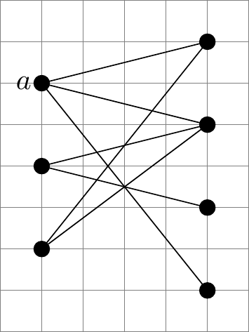

```latex
\begin{tikzpicture}[scale=0.5]

% vertex style to be used at vertex nodes
\tikzstyle{vertex}=[circle, fill, inner sep=2pt]

% help lines (comment out when done)
\draw [help lines] (-1,-4) grid (5,4);

% edges from vertex a
\draw (0,2) -- (4,3);
\draw (0,2) -- (4,1);
\draw (0,2) -- (4,-3);

% edges from vertex b
\draw (0,0) -- (4,1);
\draw (0,0) -- (4,-1);

% edges from vertex c
\draw (0,-2) -- (4,3);
\draw (0,-2) -- (4,1);

% dot at vertex a
\node [vertex] at (0,2) {};
% label at vertex x
\node [left] at (0,2) {$a$};

% dot at vertex b
\node [vertex] at (0,0) {};

% dot at vertex c
\node [vertex] at (0,-2) {};

% dot at vertex d
\node [vertex] at (4,3) {};

% dot at vertex e
\node [vertex] at (4,1) {};

% dot at vertex f
\node [vertex] at (4,-1) {};

% dot at vertex g
\node [vertex] at (4,-3) {};

\end{tikzpicture}
```

To me, after playing around with various values of the offset, an offset by 4pt looks good:
$$\verb|\node [left=4pt] at (0,2) {$a$};|$$
If you disagree, feel free to alter it. Now just insert that $\verb|=4pt|$ offset (or your preferred offset) after each $\verb|left|$ or $\verb|right|$ argument to the vertex label nodes. In order that the labels don’t get mixed up with the edges, I’m putting the labels $a$, $b$, and $c$ to the left of their respective vertices; and I’m putting the labels $d$, $e$, $f$, and $g$ to the right. The offset is not an absolute direction; it’s just a distance that modifies (in this case) either the $\verb|left|$ or the $\verb|right|$ argument to the node. This means that we don’t have to do anything different with our labels that are to the right of their vertices than we do for those that are placed to the left of their vertices.

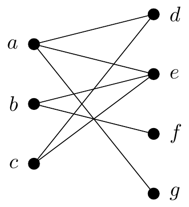

```latex
\begin{tikzpicture}[scale=0.5]

% vertex style to be used at vertex nodes
\tikzstyle{vertex}=[circle, fill, inner sep=2pt]

% help lines (comment out when done)
% \draw [help lines] (-1,-4) grid (5,4);

% edges from vertex a
\draw (0,2) -- (4,3);
\draw (0,2) -- (4,1);
\draw (0,2) -- (4,-3);

% edges from vertex b
\draw (0,0) -- (4,1);
\draw (0,0) -- (4,-1);

% edges from vertex c
\draw (0,-2) -- (4,3);
\draw (0,-2) -- (4,1);

% dot at vertex a
\node [vertex] at (0,2) {};
% label at vertex a
\node [left=4pt] at (0,2) {$a$};

% dot at vertex b
\node [vertex] at (0,0) {};
% label at vertex b
\node [left=4pt] at (0,0) {$b$};

% dot at vertex c
\node [vertex] at (0,-2) {};
% label at vertex a
\node [left=4pt] at (0,-2) {$c$};

% dot at vertex d
\node [vertex] at (4,3) {};
% label at vertex d
\node [right=4pt] at (4,3) {$d$};

% dot at vertex e
\node [vertex] at (4,1) {};
% label at vertex e
\node [right=4pt] at (4,1) {$e$};

% dot at vertex f
\node [vertex] at (4,-1) {};
% label at vertex f
\node [right=4pt] at (4,-1) {$f$};

% dot at vertex g
\node [vertex] at (4,-3) {};
% label at vertex g
\node [right=4pt] at (4,-3) {$g$};

\end{tikzpicture}
```

I think this looks like our original hand-drawn picture! Feel free to go back and do some of your own fine-tuning. When you’re ready, test your understanding with these exercises.

# Exercises for Project 2

1. Make a grid of help lines with the lower left corner of the rectangular grid at $(-2,-2)$ and the upper right corner at $(2,2)$. Using the $\verb|vertex|$ style developed in this project (modified if you like), put a dot at each non-origin intersection point of the help lines. Put a noticeably different sort of dot at the origin.
2. Modify the final graph picture in this project so that there is an additional edge from $a$ to $f$, but no edge from $b$ to $e$.
3. Modify the final graph picture in this project by adding an additional vertex $h$ at $(4,-5)$, and give it edges to $c$ and $b$.
4. Modify the final graph picture in this project by defining and using a new vertex style, called $\verb|vertex2|$, that makes dots that are about half the size as the ones in the $\verb|vertex|$ style and are also green. (If you’d like to use something fancier than green, see the [Using colors in LaTeX](https://www.overleaf.com/learn/latex/Using_colors_in_LaTeX) page in the Overleaf help documentation for a list of available $\verb|xcolor|$ colors. Be sure you’ve loaded the appropriate $\verb|xcolor|$ option before loading Ti*k*z in your preamble.)
5. Draw a picture of $K_{3,3}$, the complete bipartite graph from 3 vertices to 3 vertices, using ingredients from the code in the block for our final graph picture in this project.

The content of this site is licensed under the [Creative Commons Attribution 4.0 International License.](https://creativecommons.org/licenses/by/4.0/)